# PM 566 Midterm Project

### Covid confirmed cases by county

I can easily represent all covid confirmed cases in every county within the United States, but chose all counties within California. With there being 58 total counties within the state of California I represented the county map of all including their names. In running the grand total of confirmed covid cases by our speciifc end date of 10/06/2020 in our heat map, we see that Los Angeles county has by far the most cases compared to other counties that are much smaller in size and population.

```r
# Keeping the same matched couties in covid data set
covidGithubmelt <- covidGithubmelt[covidGithubmelt$COUNTY %in% matched, ]

# Full outer join
mergeFullOut <- merge(csvAQI_data, covidGithubmelt, all = TRUE)

# Deletes missing values for the first records of covid data in California appeared in 1/22/2020
mergeFullOut <- na.omit(mergeFullOut)
```

### Merge of Covid and AQI data sets

```r
# Could be in outout, but alos just mentioned of the extreme values for AQI and PM 2.5
mergeFullOut%>%
  group_by(COUNTY)%>%
  summarise(MinPM2.5 = min(PM2.5), MaxPM2.5 = max(PM2.5), MinAQI = min(DAILY_AQI_VALUE),
            MaxAQI = max(DAILY_AQI_VALUE))%>%
  knitr::kable()
```

| COUNTY | MinPM2.5 | MaxPM2.5 | MinAQI | MaxAQI |
| --- | --- | --- | --- | --- |
| Alameda | -0.4 | 167.7 | 0 | 218 |
| Butte | -0.6 | 329.3 | 0 | 379 |
| Calaveras | 1.6 | 134.2 | 7 | 192 |
| Colusa | -0.9 | 145.7 | 0 | 198 |
| Contra Costa | 1.7 | 145.5 | 7 | 197 |
| Del Norte | 0.8 | 16.1 | 3 | 59 |
| El Dorado | 0.6 | 5.8 | 3 | 24 |
| Fresno | -1.6 | 179.2 | 0 | 229 |
| Glenn | 0.9 | 145.2 | 4 | 197 |
| Humboldt | 2.0 | 13.3 | 8 | 54 |
| Imperial | 0.4 | 33.4 | 2 | 96 |
| Inyo | 0.0 | 194.6 | 0 | 245 |
| Kern | -0.9 | 159.7 | 0 | 210 |
| Kings | 1.0 | 147.0 | 4 | 198 |
| Lake | 1.1 | 6.9 | 5 | 29 |
| Los Angeles | -0.1 | 148.2 | 0 | 199 |
| Madera | 0.3 | 138.1 | 1 | 194 |
| Marin | 0.4 | 155.5 | 2 | 206 |
| Mariposa | 1.0 | 613.1 | 4 | 574 |
| Mendocino | 0.9 | 19.4 | 4 | 66 |
| Merced | 1.0 | 116.9 | 4 | 183 |
| Mono | 0.2 | 587.9 | 1 | 558 |
| Monterey | -0.5 | 200.3 | 0 | 250 |
| Napa | 1.0 | 145.4 | 4 | 197 |
| Nevada | -3.0 | 134.2 | 0 | 192 |
| Orange | 0.4 | 56.7 | 2 | 152 |
| Placer | 0.2 | 156.3 | 1 | 207 |
| Plumas | -2.6 | 276.8 | 0 | 327 |
| Riverside | -2.4 | 66.4 | 0 | 157 |
| Sacramento | 0.0 | 150.4 | 0 | 200 |
| San Benito | 0.7 | 89.0 | 3 | 168 |
| San Bernardino | -0.7 | 74.1 | 0 | 161 |
| San Diego | 0.0 | 66.8 | 0 | 157 |
| San Francisco | 1.0 | 147.3 | 4 | 198 |
| San Joaquin | 0.0 | 147.3 | 0 | 198 |
| San Luis Obispo | -0.2 | 304.1 | 0 | 354 |
| San Mateo | 0.8 | 124.1 | 3 | 186 |
| Santa Barbara | -1.4 | 90.1 | 0 | 169 |
| Santa Clara | 0.7 | 123.1 | 3 | 186 |
| Santa Cruz | -1.7 | 378.5 | 0 | 419 |
| Shasta | 0.1 | 13.6 | 0 | 54 |
| Siskiyou | -0.8 | 178.6 | 0 | 229 |
| Solano | 0.4 | 152.7 | 2 | 203 |
| Sonoma | 0.6 | 124.3 | 3 | 187 |
| Stanislaus | 0.1 | 112.7 | 0 | 181 |
| Sutter | -0.2 | 246.3 | 0 | 296 |
| Tehama | 0.5 | 17.5 | 2 | 62 |
| Trinity | -1.3 | 17.5 | 0 | 62 |
| Tulare | 1.0 | 151.2 | 4 | 202 |
| Ventura | -0.6 | 58.7 | 0 | 153 |
| Yolo | 0.7 | 132.3 | 3 | 191 |

### Summary of Merged data set

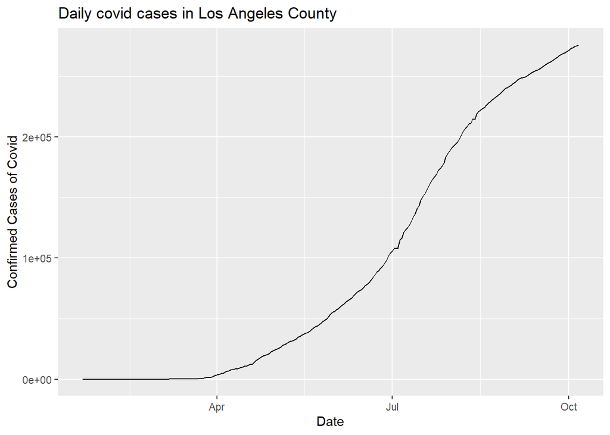

```r
# Line plot of daily covid cases in Los Angeles county
ggplot(mergeFullOut%>%
         filter(COUNTY == 'Los Angeles'), aes(x = Date, y = Confirmed))+
  geom_line()+
  labs(title = 'Daily covid cases in Los Angeles County', y = 'Confirmed Cases of Covid')
```

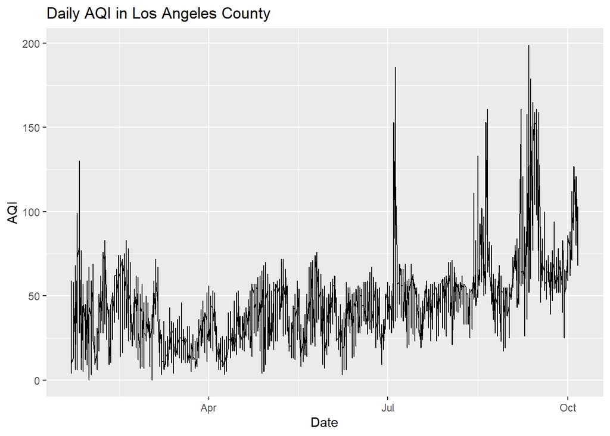

```r
# Line plot of daily AQI in Los Angeles county
ggplot(mergeFullOut%>%
         filter(COUNTY == 'Los Angeles'), aes(x = Date, y = DAILY_AQI_VALUE))+
  geom_line()+
  labs(title = 'Daily AQI in Los Angeles County', y = 'AQI')
```

### Visual Exploration

In our visualization of daily covid cases we see slight dents along our line as covid cases are quadratically increasing. These small dents could be innacuracies in the recording as wild fires, protests, and holidays could have inhibited accurate records. We also see the cyclic trend of AQI constantly rising and dropping with this trend being the most rapid at the begining of the year until July with the sharp spike due to wild fires. We see more sharp spikes as the AQI continues to rise and worsen because for frequent and long burning wild fires during the second half of the year.

```r
# Linear Regression to test the association between Confirmed covid cases and daily AQI
lm(Confirmed ~ DAILY_AQI_VALUE, data = mergeFullOut)%>%
  summary()
```

```
##
## Call:
## lm(formula = Confirmed ~ DAILY_AQI_VALUE, data = mergeFullOut)
##
## Residuals:
##     Min      1Q  Median      3Q     Max
## -131632   -9809   -6481   -3428  260822
##
## Coefficients:
##                 Estimate Std. Error t value Pr(>|t|)
## (Intercept)     2850.197    290.317   9.818   <2e-16 ***
## DAILY_AQI_VALUE  224.490      5.852  38.361   <2e-16 ***
## ---
## Signif. codes:  0 '***' 0.001 '**' 0.01 '*' 0.05 '.' 0.1 ' ' 1
##
## Residual standard error: 34100 on 32182 degrees of freedom
## Multiple R-squared:  0.04373,    Adjusted R-squared:  0.0437
## F-statistic:  1472 on 1 and 32182 DF,  p-value: < 2.2e-16
```

## Conclusion

We use linear regression to test the hypothesis whether there is an association between daily AQI on the number of confirmed covid cases. The indidual p-value for daily AQI is significant being <0.0001, we can conclude that daily AQI has a significant difference on confirmed covid cases. Our overall linear model is significant with a p-value <0.0001, which we can use our variables to predict covid cases. Our model however, has a very low $R^2$ value being that our model is only able to explain 4.37% of the variance in our model. We do find a positive association with AQI on covid cases, but to what extent is our model precise. For future analyis there might be underlying factors that could be contributing to this model such as county population. We see that counties with dense populations like Los Angeles county can have more confirmed cases compared to smaller counties in California because of the number of people per squre mile, the proximity of people occupying the county. Demographics such as age, gender, and race could be other contributing factors as different counties could all have different makeups that could be confounding of a person to contract covid.